# Chi Squared Test

```r
library(tidyverse)
library(mosaic)
library(pander)
library(DT)
library(car)
library(ggplot2)
```

## Background

Does a person’s social class depend on whether or not he/she was born in the country he/she currently lives? The data used was extracted from the orignal dataset called ‘GSS2012’. I have selected the ‘born’ and ‘class’ variables to conduct this test.

The ‘born’ variable contains data in two levels. It was recorded as a response to the question: “Were you born in this country?”, where “this country” was assumed to be the United States of America. This variable is referred to as “Birth Country” throughout this analysis.

The ‘class’ variable contains 4 levels, and was a response to the question: “If you were asked to use one of four names for your social class, which would you say you belong in: the lower class, the working class, the middle class, or the upper class?”. For convenience, this variable is referred to as “Social Status” throughout this analysis.

```r
GSS.2012 <- read.table("GSS2012.csv", sep="\t", header=TRUE)

GSS2012filtered <- GSS.2012 %>%
  filter(born == 1 |
           born == 2,
         class == 1 |
           class == 2 |
           class == 3 |
           class == 4) %>%
  mutate(born = case_when(born == 1 ~ "Yes",
                          born == 2 ~ "No")) %>%
  mutate(class = case_when(class == 1 ~ "Lower Class",
                           class == 2 ~ "Working Class",
                           class == 3 ~ "Middle Class",
                           class == 4 ~ "Upper Class"))
```

## Hypothesis

The study question of whether or not social status depends on country of residency can be written as:
$$H_0: \text{Social Status and Birth Country are independent}$$
$$H_a : \text{Social Status and Birth Country are associated}$$
We will evaluate our results at a level of significance of:
$$\alpha = 0.05$$

## Analysis

We will first take a look at the number of individuals for each of our 8 groups. We see that there is a wide range of values, from 5 to 742. We also see that the Upper Class group is by far the least represented, at least in our sample. We see that in each of the Class groups, that there are more individuals who were born in this country than individuals who were not.

```r
classborntable <- table(GSS2012filtered$class,GSS2012filtered$born)

classborntable %>%
  pander(caption = "Number of observations per group")
```

Number of observations per group

|  | No | Yes |
| --- | --- | --- |
| **Lower Class** | 23 | 177 |
| **Middle Class** | 95 | 742 |
| **Upper Class** | 5 | 60 |
| **Working Class** | 145 | 708 |

The trends we saw in our table are clearly displayed in out barplot, but it also clearly shows that in both the ‘Yes’ and ‘No’ groups, the two largest Classes represented are Middle and Working. This does tell us that there is possibly an association between class and birth country, however we need a p-value to support this claim.

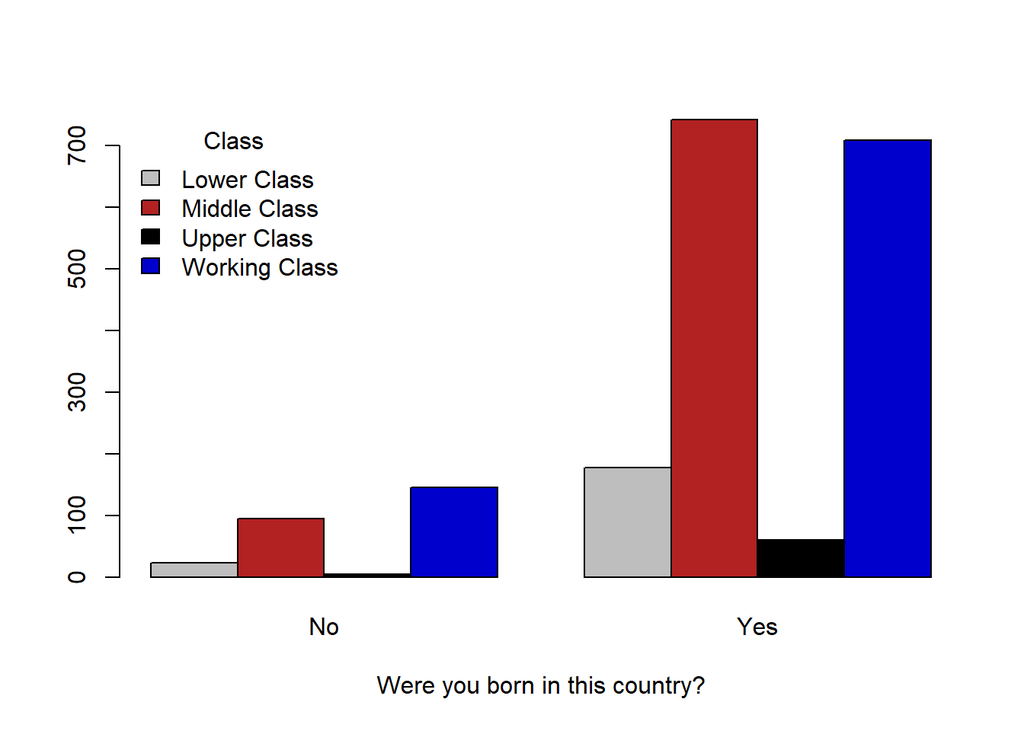

```r
barplot(table(GSS2012filtered$class,GSS2012filtered$born),
        beside=TRUE,
        legend.text=TRUE,
        col= c("gray", "firebrick", "black", "blue3"),
        main = "",
        xlab = "Were you born in this country?",
        args.legend=list(x="topleft", legend=c("Lower Class", "Middle Class", "Upper Class", "Working Class"), title="Class", bty="n"))
```

Here we can see the results of the Chi-squared test of independence run between ‘class’ and ‘born’.

```r
chisq.test(classborntable) %>%
  pander()
```

Pearson’s Chi-squared test: `classborntable`

| Test statistic | df | P value |
| --- | --- | --- |
| 14.56 | 3 | 0.002238 * * |

```r
chiresultsclassborn <- chisq.test(classborntable)
```

Now that our p-value does show there is an association and that we should reject our null hypothesis, let us check the expected counts to verify that we can trust our results:

```r
chiresultsclassborn$expected %>%
  pander()
```

|  | No | Yes |
| --- | --- | --- |
| **Lower Class** | 27.42 | 172.6 |
| **Middle Class** | 114.7 | 722.3 |
| **Upper Class** | 8.91 | 56.09 |
| **Working Class** | 116.9 | 736.1 |

As you can see above, all of the expected counts are above 5, so we can trust the results of the test.

We will also now examine our residuals to see how much our observed counts differ from expected had our null hypothesis been true:

```r
chiresultsclassborn$residuals %>%
  pander()
```

|  | No | Yes |
| --- | --- | --- |
| **Lower Class** | -0.8435 | 0.3362 |
| **Middle Class** | -1.843 | 0.7345 |
| **Upper Class** | -1.31 | 0.5221 |
| **Working Class** | 2.596 | -1.035 |

## Conclusion

Since our assumptions have been met with regards to the expected counts for each group, we can now conclude that we reject the null hypothesis based on $p = 0.002238$ which is smaller than our significance level of $\alpha = 0.05$. We therefore have sufficient evidence to conclude that the reported social class of an individual is associated with the fact of being born in this country or not.